# Categorical class 5

# Packages

```r
library(haven)      # read in SPSS data
library(ggplot2)    # plots
theme_set(theme_classic(base_size = 16)) # Set ggplot theme and increase font
library(dplyr)      # data manipulation
library(MASS)       # negative binomial regression
library(pscl)       # predprob() function for predicted counts
```

# Data

- Simulated data from Coxe, S., West, S. G., & Aiken, L. S. (2009). The analysis of count data: A gentle introduction to Poisson regression and its alternatives. *Journal of Personality Assessment, 91(2)*, 121-136.
  - `case`: Subject ID
  - `sensation`: Sensation seeking (1 to 7)
  - `gender`: 0 = female, 1 = male
  - `y`: Number of alcoholic beverages consumed on Saturday night

```r
jpa <- read_sav("jpapoisson.sav")
head(jpa, n = 10)
```

```
# A tibble: 10 × 4
    case sensation gender     y
   <dbl>     <dbl>  <dbl> <dbl>
 1     1      6.06      1     4
 2     2      5.31      1     4
 3     3      3.94      1     1
 4     4      4.30      1     6
 5     5      5.58      1     0
 6     6      4.89      1     8
 7     7      4.51      0     6
 8     8      6.16      0     1
 9     9      4.19      1     7
10    10      5.64      1     8
```

## Outcome

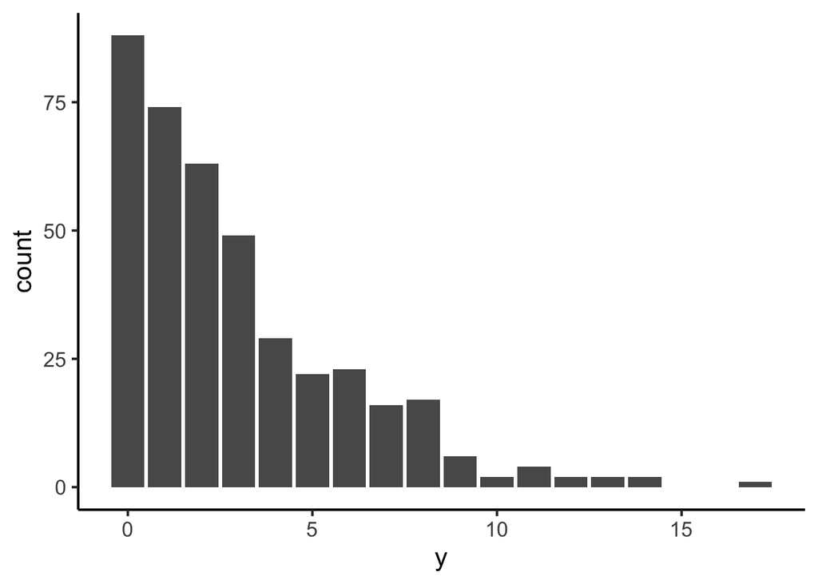

```r
ggplot(data = jpa, aes(x = y)) +
    geom_bar()
```

- The mean is 2.93
- The variance is 8.832
- Overdispersion is about the **conditional** mean and variance but…
  - Does it seem like there might be overdispersion?

# `sensation` predicts `y`

## Scatterplot of `y` vs `sensation`

- The options in `geom_smooth()` tell it to fit a Poisson regression curve
  - `method = "glm"` : use a generalized linear model
  - `method.args = list(family = "poisson")` : specifically, use a Poisson regression (i.e., count outcome)

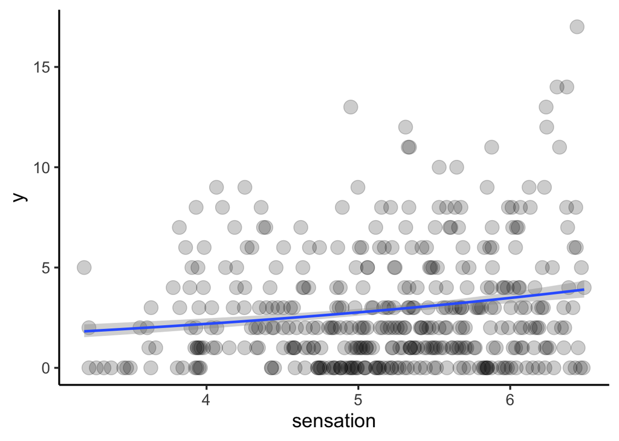

```r
ggplot(data = jpa, aes(x = sensation, y = y)) +
    geom_point(alpha = 0.2, size = 5) +
    geom_smooth(method = "glm",
                method.args = list(family = "poisson"),
                se = TRUE)
```

## Poisson regression model

- `sensation4` is centered at 4 (the midpoint of the 1 to 7 scale)
- `glm()` works very much like `lm()`
  - Additional options specify the type of GLiM
    - Here, Poisson regression (with **Poisson outcome distribution** and **log link function**) is specified by `family = poisson(link = "log")`

```r
jpa <- jpa %>% mutate(sensation4 = sensation - 4)
alc_sens4_poi <- glm(y ~ sensation4,
                     data = jpa,
                     family = poisson(link = "log"))
```

### `summary()` of the model

```r
summary(alc_sens4_poi)
```

```
Call:
glm(formula = y ~ sensation4, family = poisson(link = "log"),
    data = jpa)

Deviance Residuals:
    Min       1Q   Median       3Q      Max
-2.7912  -1.5001  -0.4624   0.8418   4.9122

Coefficients:
            Estimate Std. Error z value Pr(>|z|)
(Intercept)  0.78560    0.05977  13.144  < 2e-16 ***
sensation4   0.23148    0.03966   5.837 5.33e-09 ***
---
Signif. codes:  0 '***' 0.001 '**' 0.01 '*' 0.05 '.' 0.1 ' ' 1

(Dispersion parameter for poisson family taken to be 1)

    Null deviance: 1186.8  on 399  degrees of freedom
Residual deviance: 1151.7  on 398  degrees of freedom
AIC: 2079

Number of Fisher Scoring iterations: 5
```

- We can look at just the coefficients using the `coefficients()` function

```r
coefficients(alc_sens4_poi)
```

```
(Intercept)  sensation4
  0.7856030   0.2314809
```

- And we can select individual coefficients using `[]` for the element
  - Intercept is `[1]`
  - First predictor is `[2]`
  - Second predictor (if it exists) is `[3]`
- I’m going to save these as variables so we can call them later

```r
sens4_b0_poi <- coefficients(alc_sens4_poi)[1]
names(sens4_b0_poi) <- NULL
sens4_b1_poi <- coefficients(alc_sens4_poi)[2]
names(sens4_b1_poi) <- NULL
```

- The statements involving `NULL` are just dropping the column labels from those variables
  - Otherwise the labels will follow them around whenever we use the variables

## Overdispersed Poisson regression

- `sensation4` is centered at 4 (the midpoint of the 1 to 7 scale)
- `glm()` works very much like `lm()`
  - Additional options specify the type of GLiM
    - Here, **overdispersed** Poisson regression (with **quasi Poisson outcome distribution** and **log link function**) is specified by `family = quasipoisson(link = "log")`

```r
alc_sens4_odpoi <- glm(y ~ sensation4,
                       data = jpa,
                       family = quasipoisson(link = "log"))
```

### `summary()` of the model

```r
summary(alc_sens4_odpoi)
```

```
Call:
glm(formula = y ~ sensation4, family = quasipoisson(link = "log"),
    data = jpa)

Deviance Residuals:
    Min       1Q   Median       3Q      Max
-2.7912  -1.5001  -0.4624   0.8418   4.9122

Coefficients:
            Estimate Std. Error t value Pr(>|t|)
(Intercept)  0.78560    0.10086   7.789 5.91e-14 ***
sensation4   0.23148    0.06692   3.459 0.000601 ***
---
Signif. codes:  0 '***' 0.001 '**' 0.01 '*' 0.05 '.' 0.1 ' ' 1

(Dispersion parameter for quasipoisson family taken to be 2.847168)

    Null deviance: 1186.8  on 399  degrees of freedom
Residual deviance: 1151.7  on 398  degrees of freedom
AIC: NA

Number of Fisher Scoring iterations: 5
```

- We can look at just the coefficients using the `coefficients()` function

```r
coefficients(alc_sens4_odpoi)
```

```
(Intercept)  sensation4
  0.7856030   0.2314809
```

- And we can select individual coefficients using `[]` for the element
  - Intercept is `[1]`
  - First predictor is `[2]`
  - Second predictor (if it exists) is `[3]`
- I’m going to save these as variables so we can call them later

```r
sens4_b0_odpoi <- coefficients(alc_sens4_odpoi)[1]
names(sens4_b0_odpoi) <- NULL
sens4_b1_odpoi <- coefficients(alc_sens4_odpoi)[2]
names(sens4_b1_odpoi) <- NULL
```

- The statements involving `NULL` are just dropping the column labels from those variables
  - Otherwise the labels will follow them around whenever we use the variables

### Overdispersion

- You can print the overdispersion parameter ($\psi$) using

```r
psi_odpoi <- summary(alc_sens4_odpoi)$dispersion
psi_odpoi
```

```
[1] 2.847168
```

- If there is overdispersion, the $\psi$ value will be greater than 1

## Negative binomial regression

- `sensation4` is centered at 4 (the midpoint of the 1 to 7 scale)
- Negative binomial regression uses the `glm.nb()` function from the **MASS** package
  - It also works similarly to `lm()`
  - Specify data
  - Specify `outcome ~ predictor` relationship

```r
alc_sens4_nb <- glm.nb(data = jpa,
                       y ~ sensation4)
```

### `summary()` of the model

```r
summary(alc_sens4_nb)
```

```
Call:
glm.nb(formula = y ~ sensation4, data = jpa, init.theta = 1.392859438,
    link = log)

Deviance Residuals:
    Min       1Q   Median       3Q      Max
-1.9207  -0.9158  -0.2809   0.4658   2.1349

Coefficients:
            Estimate Std. Error z value Pr(>|z|)
(Intercept)  0.79937    0.09831   8.131 4.26e-16 ***
sensation4   0.22050    0.06822   3.232  0.00123 **
---
Signif. codes:  0 '***' 0.001 '**' 0.01 '*' 0.05 '.' 0.1 ' ' 1

(Dispersion parameter for Negative Binomial(1.3929) family taken to be 1)

    Null deviance: 463.49  on 399  degrees of freedom
Residual deviance: 452.56  on 398  degrees of freedom
AIC: 1772.1

Number of Fisher Scoring iterations: 1

              Theta:  1.393
          Std. Err.:  0.163

 2 x log-likelihood:  -1766.091
```

- We can look at just the coefficients using the `coefficients()` function

```r
coefficients(alc_sens4_nb)
```

```
(Intercept)  sensation4
  0.7993708   0.2204963
```

- And we can select individual coefficients using `[]` for the element
  - Intercept is `[1]`
  - First predictor is `[2]`
  - Second predictor (if it exists) is `[3]`
- I’m going to save these as variables so we can call them later

```r
sens4_b0_nb <- coefficients(alc_sens4_nb)[1]
names(sens4_b0_nb) <- NULL
sens4_b1_nb <- coefficients(alc_sens4_nb)[2]
names(sens4_b1_nb) <- NULL
```

- The statements involving `NULL` are just dropping the column labels from those variables
  - Otherwise the labels will follow them around whenever we use the variables

### Overdispersion

- You can print the overdispersion parameter ($\theta = \frac{1}{\alpha}$) using

```r
theta_nb <- summary(alc_sens4_nb)$theta
theta_nb
```

```
[1] 1.392859
```

```r
alpha_nb <- 1 / theta_nb
alpha_nb
```

```
[1] 0.7179475
```

- If there is overdispersion, the $\alpha$ value will be greater than 0

## Interpretation

- This is the interpretation for the Poisson and overdispersed Poisson models
  - The logic for negative binomial regression interpretation is the same, but the actual numbers will be different

### Intercept

- *Predicted count* of alcoholic drinks (`y`) when sensation seeking = 4 (`sensation4` = 0)
  - $\hat{Y} = \hat{\mu} = e^{b_0}$ =

```r
count_X0_poi <- exp(sens4_b0_poi)
count_X0_poi
```

```
[1] 2.193729
```

- A person with `sensation4` = 0 (`sensation` = 4) is predicted to drink 2.19 alcoholic drinks
- You can also convert it to the *natural log of the predicted count* metric:

```r
log_X0_poi <- log(count_X0_poi)
log_X0_poi
```

```
[1] 0.785603
```

- The *natural log of the predicted number of drinks* for a person with `sensation4` = 0 (`sensation` = 4) is 0.79

### Slope

- From the slope, you can calculate the **rate ratio (RR)**

```r
RR <- exp(sens4_b1_poi)
RR
```

```
[1] 1.260465
```

- The **rate ratio** is the multiplicative change in the predicted count for a 1 unit change in the predictor
  - **Constant** multiplicative change
  - For every 1 unit increase in `sensation4`, we expect the predicted count to get **multiplied** by 1.26
  - You can also interpret this as a **$26$ percent** increase

## Predicted values

- This is just one way to do this that I find the easiest
  - Grab the $b_0$ and $b_1$ values from the output
    - We already saved these above as variables: `sens4_b0_poi` and `sens4_b1_poi` for Poisson regression, etc.
  - Create some X values that correspond to the predictor
    - `sensation` ranges from $1$ to $7$ (in theory)
    - `sensation4` ranges from $-3$ to $3$ (in theory)
    - Don’t include too many values or the table will get too large
  - Calculate the **predicted count** using the equations from lecture
  - Combine all the variables into a data frame

```r
x <- c(-3, -2, -1, 0, 1, 2, 3)
pred_count_poi <- exp(sens4_b0_poi + sens4_b1_poi * x)
pred_count_odpoi <- exp(sens4_b0_odpoi + sens4_b1_odpoi * x)
pred_count_nb <- exp(sens4_b0_nb + sens4_b1_nb * x)
predicted <- data.frame(x, pred_count_poi, pred_count_odpoi, pred_count_nb)
```

- If you’re using markdown or Quarto with R, you can print the table in HTML with formatting to look nicer and be a bit easier to read

```r
knitr::kable(predicted, digits = 2, row.names = F)
```

| x | pred_count_poi | pred_count_odpoi | pred_count_nb |
| --- | --- | --- | --- |
| -3 | 1.10 | 1.10 | 1.15 |
| -2 | 1.38 | 1.38 | 1.43 |
| -1 | 1.74 | 1.74 | 1.78 |
| 0 | 2.19 | 2.19 | 2.22 |
| 1 | 2.77 | 2.77 | 2.77 |
| 2 | 3.49 | 3.49 | 3.46 |
| 3 | 4.39 | 4.39 | 4.31 |

- Otherwise, just print the table
  - I rounded all values to 3 decimal places

```r
round(predicted, 3)
```

```
   x pred_count_poi pred_count_odpoi pred_count_nb
1 -3          1.095            1.095         1.148
2 -2          1.381            1.381         1.431
3 -1          1.740            1.740         1.784
4  0          2.194            2.194         2.224
5  1          2.765            2.765         2.773
6  2          3.485            3.485         3.457
7  3          4.393            4.393         4.310
```

- Plot the regression lines
  - I’m only including the Poisson and negative binomial models because the overdispersed Poisson model is the same as the Poisson model
    - (Because the coefficients are the same)
  - Solid line is Poisson, dashed line is negative binomial

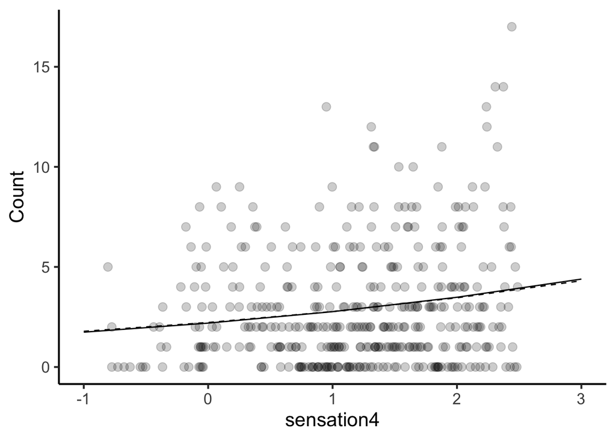

```r
ggplot(data = jpa, aes(x = sensation4, y = y)) +
    geom_point(size = 3, alpha = 0.2) +
    geom_line(data = predicted,
              aes(x = x, y = pred_count_poi),
              linetype = "solid") +
    geom_line(data = predicted,
              aes(x = x, y = pred_count_nb),
              linetype = "dashed") +
    labs(x = "sensation4", y = "Count") +
    xlim(-1,3)
```

## Plot of predicted probability values

- Some code adapted from the Atkins & Gallop (2007) article (Figure 1)
  - `predprob()` function from **pscl** package calculates predicted probabilities of count values based on the model
    - Predicted probability of *each outcome value* for each person
      - Not just the person’s predicted value
    - Then take the mean for each outcome value (column) using `apply()`
      - The `2` tells it to get the mean for each *column*
      - One predicted probability for each value of the outcome
    - Put those in a dataset with the possible outcome values (0 to 17)

```r
phat.pois <- predprob(alc_sens4_poi)
phat.pois.mn <- apply(phat.pois, 2, mean)
phat.pois.mn
```

```
           0            1            2            3            4            5
6.056008e-02 1.623542e-01 2.248151e-01 2.141266e-01 1.575259e-01 9.526311e-02
           6            7            8            9           10           11
4.921052e-02 2.227976e-02 9.003242e-03 3.291494e-03 1.100031e-03 3.388502e-04
          12           13           14           15           16           17
9.685088e-05 2.582863e-05 6.457106e-06 1.519367e-06 3.376747e-07 7.110293e-08
```

```r
phat.nb <- predprob(alc_sens4_nb)
phat.nb.mn <- apply(phat.nb, 2, mean)
phat.nb.mn
```

```
          0           1           2           3           4           5
0.211057742 0.196228947 0.157236212 0.119481715 0.088439808 0.064485584
          6           7           8           9          10          11
0.046583338 0.033448680 0.023921853 0.017063203 0.012149942 0.008642031
         12          13          14          15          16          17
0.006143087 0.004365497 0.003102169 0.002204766 0.001567418 0.001114748
```

```r
x <- seq(0, 17, 1)
probs <- data.frame(x, phat.pois.mn, phat.nb.mn)
probs
```

```
    x phat.pois.mn  phat.nb.mn
0   0 6.056008e-02 0.211057742
1   1 1.623542e-01 0.196228947
2   2 2.248151e-01 0.157236212
3   3 2.141266e-01 0.119481715
4   4 1.575259e-01 0.088439808
5   5 9.526311e-02 0.064485584
6   6 4.921052e-02 0.046583338
7   7 2.227976e-02 0.033448680
8   8 9.003242e-03 0.023921853
9   9 3.291494e-03 0.017063203
10 10 1.100031e-03 0.012149942
11 11 3.388502e-04 0.008642031
12 12 9.685088e-05 0.006143087
13 13 2.582863e-05 0.004365497
14 14 6.457106e-06 0.003102169
15 15 1.519367e-06 0.002204766
16 16 3.376747e-07 0.001567418
17 17 7.110293e-08 0.001114748
```

- Plot of histogram of observed outcome values
  - Plus predicted values for Poisson regression model (solid line)
  - Plut predicted values for negative binomial model (dashed line)

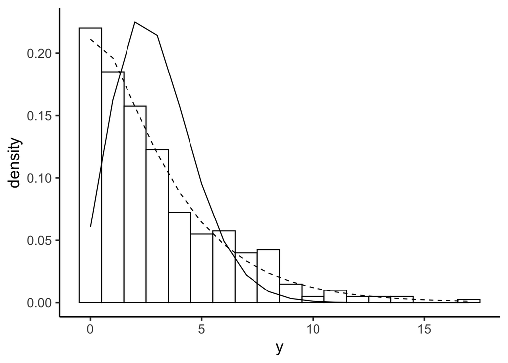

```r
ggplot(data = jpa, aes(x = y, y = ..density..)) +
    geom_histogram(binwidth = 1, fill = "white", color = "black") +
    geom_line(data = probs,
              aes(x = x, y = phat.pois.mn),
              linetype = "solid") +
    geom_line(data = probs,
              aes(x = x, y = phat.nb.mn),
              linetype = "dashed")
```

- The very latest version of **ggplot2** has deprecated the `..density..` notation
  - But it still works
  - If you don’t want to see the message, replace `..density..` with `after_stat(density)`

# Class task

1. Create a scatterplot of `y` versus `gender`
2. Run a Poisson regression model with `gender` predicting `y`
   - Interpret the coefficients from the model (count metric)
3. Run a negative binomial regression model with `gender` predicting `y`
   - Interpret the coefficients from the model (count metric)
4. Calculate the predicted `y` for each level of `gender`

# Questions for next time

- How much variance in `y` is explained by `sensation`?
  - By `gender`?
  - By both `sensation` and `gender`? (We haven’t run this model yet)
- Based on the predicted counts, the *negative binomial* model fits well
  - Do we have excess zeroes?
  - Would that be a better model?